# Farm Science Review - CAUV Program

Robert Dinterman

18th and 19th of September 2018

# Questions

## What is the CAUV Program, why does it exist, and what the heck goes into it?

- Optional program for farmers with more than 10 acres of land to enroll in calculating their property tax value based off of agricultural conditions instead of market conditions, almost everyone participates
- Started in the 1970s – its primary stated intent has been to combat urbanization which can put upward pressure on farms property values and hence their tax
- The objective of the CAUV program was to discourage the sale of farmland for development purposes by providing the farmer with a tax break (http://www.the-daily-record.com/opinion/20120214/understanding-cauv-tax-program)
- Attempts to tie the property value of a farm to its agricultural use and not its “next best use”
- The formula involves:
  - Soil type/quality, yields/prices/non-land costs for corn/soybeans/wheat, and a capitalization rate
  - Higher quality soil has higher CAUV
  - All values are based on at least 5 historical values, usually through an Olympic average where the highest and lowest values are dropped

All categories are Olympic averages with the exception of rotation and yields.

| Tax Year | Capitalization Rate | Yields | Prices | Non-Land Costs | Rotation |
| --- | --- | --- | --- | --- | --- |
| 2005 | 1999-2005 | 1984 | 1997-2003 | 1998-2004 | ad hoc |
| 2006 | 2000-2006 | 1995-2004 | 1998-2004 | 1999-2005 | ad hoc |
| 2007 | 2001-2007 | 1996-2005 | 1999-2005 | 2000-2006 | ad hoc |
| 2008 | 2002-2008 | 1997-2006 | 2000-2006 | 2001-2007 | ad hoc |
| 2009 | 2003-2009 | 1998-2007 | 2001-2007 | 2002-2008 | ad hoc |
| 2010 | 2004-2010 | 1999-2008 | 2002-2008 | 2003-2009 | 2004-2008 |
| 2011 | 2005-2011 | 2000-2009 | 2003-2009 | 2004-2010 | 2005-2009 |
| 2012 | 2006-2012 | 2001-2010 | 2004-2010 | 2005-2011 | 2006-2010 |
| 2013 | 2007-2013 | 2002-2011 | 2005-2011 | 2006-2012 | 2007-2011 |
| 2014 | 2008-2014 | 2003-2012 | 2006-2012 | 2007-2013 | 2008-2012 |
| 2015 | 2009-2015 | 2005-2014 | 2008-2014 | 2009-2015 | 2010-2014 |
| 2016 | 2010-2016 | 2006-2015 | 2009-2015 | 2010-2016 | 2011-2015 |
| 2017 | 2011-2017 | 2007-2016 | 2010-2016 | 2011-2017 | 2012-2016 |
| 2018 | 2012-2018 | 2008-2017 | 2011-2017 | 2012-2018 | 2013-2017 |
| 2019 | 2013-2019 | 2009-2018 | 2012-2018 | 2013-2019 | 2014-2018 |
| Future | current-6 years ago | previous-11 years ago | previous-7 years ago | current-6 years ago | previous-5 years ago |
| Years | 7 Olympic | 10 Average, lag | 7 Olympic, lag | 7 Olympic | 5 Average, lag |

Sources and timing of release:

1. Capitalization Rate - interest rates come from Ohio Department of Taxation while the equity rate comes from [USDA-ERS](https://www.ers.usda.gov/data-products/farm-income-and-wealth-statistics/) which has updates each year in February (should be considered “official”), August, and November.
   - [USDA data files](https://www.ers.usda.gov/data-products/farm-income-and-wealth-statistics/data-files-us-and-state-level-farm-income-and-wealth-statistics/), should select the Farm Income Statements and then returns to operators
2. [Crop Production Reports](https://usda.mannlib.cornell.edu/MannUsda/viewDocumentInfo.do?documentID=1046) affects yields and rotation. Typically there is an August, September, October, and November forecast. Then [finalized values](https://usda.mannlib.cornell.edu/MannUsda/viewDocumentInfo.do?documentID=1047) occur in January of the following year. The USDA Quick Stats API will incorrectly place the most recent forecast value for the current year in the “YEAR” reference period. This needs to be accounted for.
3. Prices are for the marketing year period which are published by the [USDA-NASS](http://usda.mannlib.cornell.edu/MannUsda/viewDocumentInfo.do?documentID=1002) and have monthly prices. However, the official values come out around March each year.
4. Non-Land Costs maintained at the [Ohio State Extension website](https://farmoffice.osu.edu/farm-management-tools/farm-budgets) and there will usually be an initial estimate for the budgets in October of that year with the final update usually around May.

## Has this been an effective program?

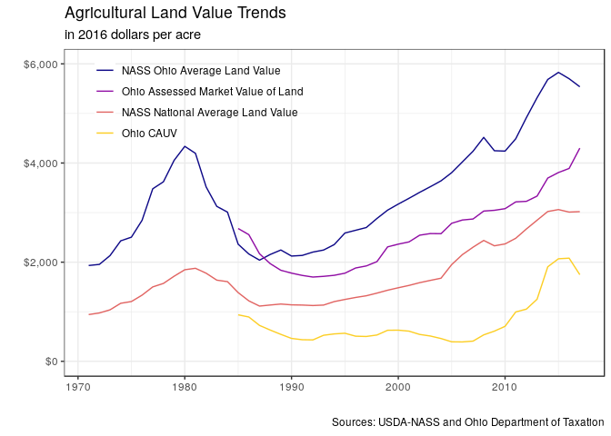

| year | Ohio Assessed Market Value of Land | Ohio CAUV | Ratio | Property Tax |
| --- | --- | --- | --- | --- |
| 1985 | $1,378 | $482 | 0.3500964 | $NA |
| 1986 | $1,341 | $469 | 0.3500119 | $NA |
| 1987 | $1,166 | $389 | 0.3338258 | $NA |
| 1988 | $1,097 | $351 | 0.3201732 | $4.90 |
| 1989 | $1,061 | $314 | 0.2961261 | $4.62 |
| 1990 | $1,066 | $277 | 0.2596851 | $4.19 |
| 1991 | $1,073 | $270 | 0.2514389 | $4.04 |
| 1992 | $1,077 | $274 | 0.2541885 | $4.16 |
| 1993 | $1,112 | $341 | 0.3066224 | $5.36 |
| 1994 | $1,149 | $366 | 0.3187499 | $5.47 |
| 1995 | $1,202 | $383 | 0.3186032 | $5.89 |
| 1996 | $1,296 | $349 | 0.2693014 | $5.38 |
| 1997 | $1,348 | $351 | 0.2605236 | $5.36 |
| 1998 | $1,424 | $376 | 0.2638681 | $5.71 |
| 1999 | $1,658 | $450 | 0.2712735 | $6.83 |
| 2000 | $1,736 | $462 | 0.2659053 | $6.82 |
| 2001 | $1,809 | $457 | 0.2527020 | $6.82 |
| 2002 | $1,941 | $414 | 0.2132366 | $6.22 |
| 2003 | $2,005 | $397 | 0.1981093 | $6.02 |
| 2004 | $2,058 | $368 | 0.1786110 | $5.68 |
| 2005 | $2,297 | $325 | 0.1412912 | $5.16 |
| 2006 | $2,424 | $333 | 0.1372609 | $5.32 |
| 2007 | $2,506 | $356 | 0.1420226 | $5.71 |
| 2008 | $2,697 | $475 | 0.1760780 | $7.69 |
| 2009 | $2,732 | $546 | 0.1998910 | $8.88 |
| 2010 | $2,796 | $641 | 0.2293531 | $10.57 |
| 2011 | $2,980 | $923 | 0.3095819 | $15.52 |
| 2012 | $3,046 | $994 | 0.3264738 | $16.92 |
| 2013 | $3,196 | $1,202 | 0.3758907 | $20.63 |
| 2014 | $3,609 | $1,862 | 0.5158883 | $32.60 |
| 2015 | $3,757 | $2,041 | 0.5431598 | $35.04 |
| 2016 | $3,890 | $2,081 | 0.5348508 | $35.66 |
| 2017 | $4,387 | $1,783 | 0.4063974 | $30.58 |

(Note these are for assessed properties and does not treat soil types equally like later calculations do)

## What changes have been made to the program and why?

- Document main changes:
  - 2006 yield update started an increase - Farm Bureau had concerns the program would be revoked due to unjustifiably low CAUV values
    - Then high crop prices pushed the values upward
    - Declining interest rates also caused an upward rise in CAUV
  - Large complaints about the rapidly increasing property tax bills of farmers: the state average was about $5.32 per acre in 2006 and quickly quadrupled to $20.63 in 2013.
  - 2015 adjustment to decrease lags in components began the decline in CAUV values and higher clearing/drainage costs
  - 2017 changed in capitalization rate which will be phased in over a period of time
- [Wood County Document](http://www.co.wood.oh.us/auditor/pdfs/2015/CAUV/History%20of%20CAUV.pdf)
- New minimum values of $350 for cropland and $230 for woodland
  - Woodland value is the cropland value less clearing and drainage costs. Clearing is now $1,000 per acre (up from $500 in 2014) and drainage is $800 for somewhat poorly drained, poorly drained, very poorly drained, and saturated (ie soils which are not well drained)
  - Land in conservation is now assessed $230, the lowest value that can occur

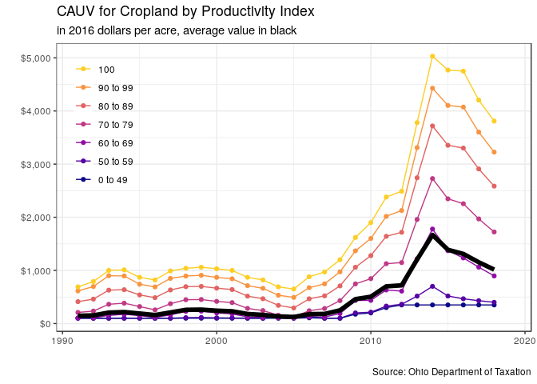

| year | corn_price | corn_price_odt | corn_price_cauv_exp | soy_price | soy_price_odt | soy_price_cauv_exp | wheat_price | wheat_price_odt | wheat_price_cauv_exp |
| --- | --- | --- | --- | --- | --- | --- | --- | --- | --- |
| 2006 | $3.08 | $1.99 | $1.97 | $6.46 | $4.84 | $5.04 | $3.35 | $2.49 | $2.59 |
| 2007 | $4.29 | $1.96 | $2.06 | $9.93 | $4.89 | $5.38 | $5.37 | $2.64 | $2.87 |
| 2008 | $4.21 | $2.02 | $2.29 | $10.30 | $5.19 | $5.83 | $5.82 | $2.89 | $3.05 |
| 2009 | $3.55 | $2.29 | $2.70 | $9.78 | $5.60 | $6.63 | $4.41 | $3.05 | $3.61 |
| 2010 | $5.45 | $2.66 | $2.89 | $11.50 | $6.41 | $7.97 | $5.21 | $3.41 | $3.77 |
| 2011 | $6.44 | $2.89 | $3.26 | $13.00 | $7.22 | $8.57 | $6.73 | $3.64 | $4.22 |
| 2012 | $7.09 | $3.19 | $3.93 | $14.60 | $7.74 | $9.08 | $7.94 | $3.98 | $4.55 |
| 2013 | $4.41 | $3.91 | $4.54 | $13.00 | $8.98 | $10.40 | $6.54 | $4.54 | $5.19 |
| 2014 | $3.78 | $4.48 | $4.70 | $10.30 | $10.13 | $11.07 | $5.60 | $5.16 | $5.64 |
| 2015 | $3.89 | $4.55 | $4.57 | $9.16 | $11.09 | $11.08 | $4.57 | $5.67 | $5.69 |
| 2016 | $3.61 | $4.49 | $4.50 | $9.66 | $10.91 | $10.91 | $4.25 | $5.53 | $5.53 |
| 2017 | $3.55 | $4.51 | $4.50 | $9.50 | $10.83 | $10.83 | $4.90 | $5.53 | $5.53 |
| 2018 | $NA | $4.18 | $4.17 | $NA | $10.43 | $10.43 | $NA | $5.52 | $5.52 |
| 2019 | $NA | $NA | $3.75 | $NA | $NA | $9.79 | $NA | $NA | $5.13 |

## So the new 2017 changes have affected me already?

- Not quite, for one this will be phased in over the 2016 CAUV values so as to not reduce values dramatically.
- Depends on your county, 2017 had about half the state adjust while 2018 has a quarter and 2019 the remaining quarter.
  - CAUV values will update once every three years, but it depends on which county you live in. There will be about a quarter of the counties updated this year, last tax season had roughly half and in 2019 there will be the remaining counties updated.
  - Starting in 2020, there will be no more phase-in procedure

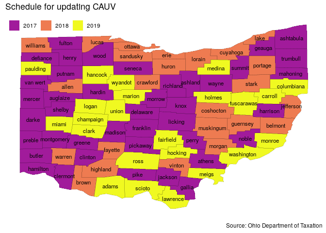

## How much will this phase in process affect my CAUV?

- In 2017 estimates, the average soil CAUV is around $1,150 but this includes a phased in adjustment factor of around $150. If this were 2020, then we would have seen values of around $1,000
- For 2018, the average soil CAUV was $1,015 but the phase-in adjustment was around $140.
- Our current projections for 2019 is to see about a 13% decline in CAUV value of around $890 which would have a phase-in of about $130.
  - This is the last year of the phase-in, the 2020 values would be $760 if there are no changes to CAUV values because the phase-in would not apply.

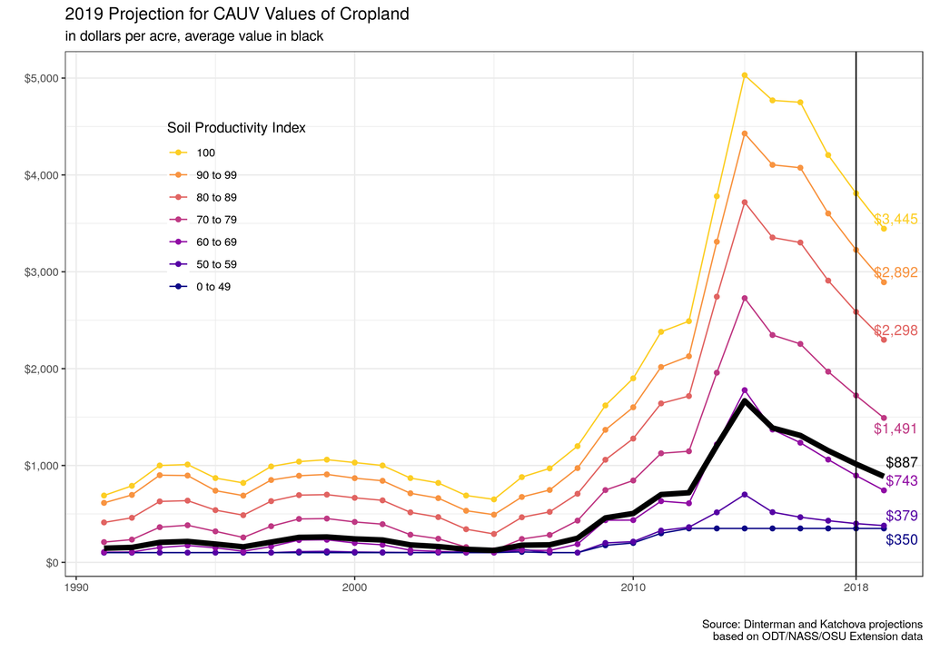

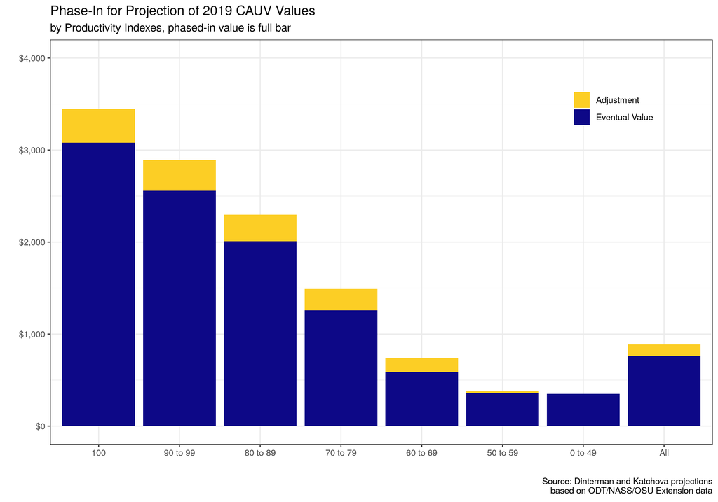

| year | avg_cauv | indx_49 | indx_59 | indx_69 | indx_79 | indx_89 | indx_99 | indx_100 | avg_change |
| --- | --- | --- | --- | --- | --- | --- | --- | --- | --- |
| 1991 | $146 | $100 | $101 | $106 | $209 | $412 | $614 | $690 | NA% |
| 1992 | $154 | $100 | $100 | $107 | $235 | $460 | $696 | $790 | 5.48% |
| 1993 | $206 | $100 | $100 | $153 | $363 | $629 | $900 | $1,000 | 33.77% |
| 1994 | $216 | $100 | $100 | $174 | $383 | $637 | $896 | $1,010 | 4.85% |
| 1995 | $189 | $100 | $101 | $150 | $320 | $539 | $740 | $870 | -12.50% |
| 1996 | $160 | $100 | $100 | $114 | $257 | $487 | $689 | $820 | -15.34% |
| 1997 | $209 | $100 | $100 | $163 | $373 | $632 | $850 | $990 | 30.62% |
| 1998 | $258 | $100 | $111 | $230 | $448 | $694 | $894 | $1,040 | 23.44% |
| 1999 | $262 | $100 | $114 | $233 | $452 | $699 | $908 | $1,060 | 1.55% |
| 2000 | $242 | $100 | $107 | $200 | $417 | $666 | $869 | $1,030 | -7.63% |
| 2001 | $231 | $100 | $104 | $181 | $394 | $640 | $842 | $1,000 | -4.55% |
| 2002 | $180 | $100 | $102 | $125 | $285 | $516 | $713 | $870 | -22.08% |
| 2003 | $163 | $100 | $101 | $113 | $244 | $467 | $663 | $820 | -9.44% |
| 2004 | $135 | $100 | $114 | $104 | $157 | $342 | $533 | $690 | -17.18% |
| 2005 | $123 | $100 | $106 | $101 | $124 | $293 | $492 | $650 | -8.89% |
| 2006 | $177 | $108 | $134 | $125 | $241 | $465 | $675 | $880 | 43.90% |
| 2007 | $181 | $100 | $100 | $123 | $283 | $521 | $747 | $970 | 2.26% |
| 2008 | $249 | $100 | $100 | $188 | $431 | $708 | $973 | $1,200 | 37.57% |
| 2009 | $459 | $176 | $200 | $435 | $746 | $1,059 | $1,368 | $1,620 | 84.34% |
| 2010 | $505 | $200 | $214 | $436 | $845 | $1,278 | $1,601 | $1,900 | 10.02% |
| 2011 | $700 | $300 | $328 | $632 | $1,126 | $1,641 | $2,017 | $2,380 | 38.61% |
| 2012 | $719 | $350 | $363 | $610 | $1,147 | $1,717 | $2,128 | $2,490 | 2.71% |
| 2013 | $1,205 | $350 | $516 | $1,218 | $1,958 | $2,743 | $3,310 | $3,780 | 67.59% |
| 2014 | $1,668 | $350 | $700 | $1,778 | $2,728 | $3,718 | $4,428 | $5,030 | 38.42% |
| 2015 | $1,388 | $350 | $518 | $1,371 | $2,347 | $3,354 | $4,104 | $4,770 | -16.79% |
| 2016 | $1,310 | $350 | $466 | $1,235 | $2,255 | $3,302 | $4,074 | $4,750 | -5.62% |
| 2017 | $1,153 | $350 | $430 | $1,061 | $1,969 | $2,909 | $3,602 | $4,205 | -11.98% |
| 2018 | $1,015 | $350 | $400 | $896 | $1,723 | $2,586 | $3,226 | $3,810 | -11.97% |
| 2019 | $887 | $350 | $379 | $743 | $1,491 | $2,298 | $2,892 | $3,445 | -12.57% |

## How do you make these projections?

- Based off of current expectations of prices, yields, non-land costs, and interest rates
  - Prices carry forward the most recent USDA values
  - Yields and rotation use the August forecast values from USDA which, will be updated with the September, October, and November forecasts. Finalized in January 2019.
  - Non-land costs use Ohio State Extension budgets carrying forward values from 2018 as place-holder for 2019. Will be updated when preliminary budget estimates are released
  - Interest rates carry forward current values

## Once this takes effect fully – I will definitely see a decrease in my CAUV?

- It is highly likely but not certain, it will still depend on yield/price and interest rate trends
- Even if you realize a decreased CAUV, your tax rate might change
- **CAUV is different than property tax**
  - CAUV gives the property value of which you’re taxed but not the actual tax you pay
  - Ohio has a taxable value of 35% property value, but then the “millage rate” will depend on your county, municipality, and school district
  - Millage rates might increase, so your CAUV might go down but tax rate could increase
- Keep in mind that while the average in Ohio for property tax per acre was about $31.55 the minimum was $5.93 for monroe and maximum was $98.29 for cuyahoga

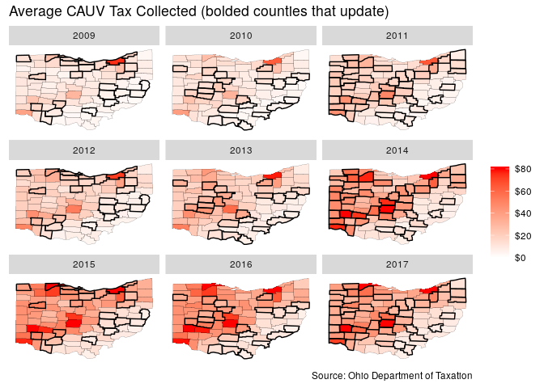

## How does CAUV compare to other states?

All of the surrounding states do provide some sort of differential tax treatment

- Indiana is most similar in using a use-value formulation but also use cash rents in their formula
  - $35 to $42 property tax paid per acre of farmland in Indiana for 2016
- Illinois is about $17 to $20 per acre
- West Virginia: about $1.50 per acre
- Kentucky has been in trouble with improper classification of farmland (used for commercial development but received preferable farmland taxation.)

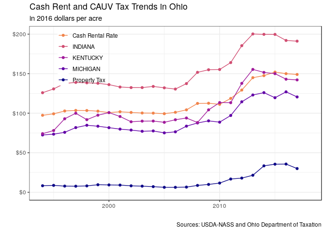

# Was there a change in the conservation assessment?

Yes, in 2017 one large change was that land enrolled in conservation is now assessed at the lowest value ($230) whereas before its CAUV value was still based on the soil type.

- In 2017, there were 16,007,314 acres enrolled in CAUV – which has been pretty stable.
  - There were 257,519 acres enrolled in CRP
  - Not a *large* issue, but still of interest.
- Will be interesting to keep track of enrollment, farmers have a bit more incentive to enroll into CRP

Acreage history for CRP:

| YEAR | US | OHIO | fraction |
| --- | --- | --- | --- |
| 1986 | 1,926,692 | 8,171 | 0.424% |
| 1987 | 15,331,971 | 99,651 | 0.650% |
| 1988 | 23,845,154 | 139,207 | 0.584% |
| 1989 | 28,850,447 | 195,669 | 0.678% |
| 1990 | 32,496,627 | 243,152 | 0.748% |
| 1991 | 32,969,180 | 262,679 | 0.797% |
| 1992 | 33,966,698 | 313,153 | 0.922% |
| 1993 | 34,988,426 | 365,984 | 1.046% |
| 1994 | 34,988,426 | 365,984 | 1.046% |
| 1995 | 34,952,266 | 364,534 | 1.043% |
| 1996 | 34,478,302 | 352,961 | 1.024% |
| 1997 | 32,792,055 | 327,177 | 0.998% |
| 1998 | 30,108,903 | 320,145 | 1.063% |
| 1999 | 29,797,800 | 296,109 | 0.994% |
| 2000 | 31,394,934 | 280,632 | 0.894% |
| 2001 | 33,578,202 | 300,540 | 0.895% |
| 2002 | 33,934,239 | 304,836 | 0.898% |
| 2003 | 34,080,953 | 301,552 | 0.885% |
| 2004 | 34,676,658 | 276,465 | 0.797% |
| 2005 | 34,871,389 | 287,956 | 0.826% |
| 2006 | 35,972,520 | 329,639 | 0.916% |
| 2007 | 36,740,293 | 362,311 | 0.986% |
| 2008 | 34,584,010 | 352,248 | 1.019% |
| 2009 | 33,692,761 | 347,521 | 1.031% |
| 2010 | 31,270,394 | 343,584 | 1.099% |
| 2011 | 31,103,325 | 343,619 | 1.105% |
| 2012 | 29,505,418 | 336,198 | 1.139% |
| 2013 | 26,819,626 | 317,073 | 1.182% |
| 2014 | 25,429,615 | 278,409 | 1.095% |
| 2015 | 24,167,810 | 267,227 | 1.106% |
| 2016 | 23,865,634 | 263,381 | 1.104% |
| 2017 | 23,415,018 | 257,519 | 1.100% |

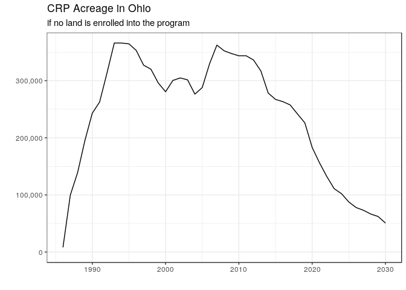